# Elbow Plot Metrics

R Programming

Single-cell RNA-seq

In this lesson, participants learn how to determine the appropriate number of principal components (PCs) to use in downstream single-cell RNA-seq analyses by combining visual and quantitative approaches. After generating an elbow plot with Seurat, participants explore two complementary metrics that identify where variance contributions taper off. By comparing cumulative variance explained and percent changes between consecutive PCs, participants gain an understanding of how many PCs capture the majority of biological signal for clustering.

Authors

Meeta Mistry

Amélie Julé

Will Gammerdinger

Noor Sohail

Published

May 30, 2025

Keywords

R, Seurat, PCA, Elbow plot

## Elbow plot: quantitative approach

The elbow plot is helpful when determining how many PCs we need to capture the majority of the variation in the data. The elbow plot visualizes the standard deviation of each PC. Where the elbow appears is usually the threshold for identifying the majority of the variation. However, this method can be a bit subjective about where the elbow is located.

We will try the top 40 dimensions:

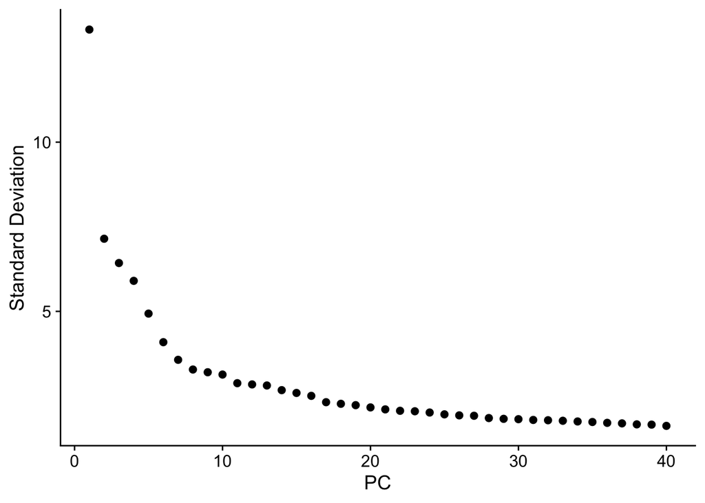

```r
# Plot the elbow plot
ElbowPlot(object = seurat_integrated,
          ndims = 40)
```

1. The point where the principal components only contribute 5% of standard deviation and the principal components cumulatively contribute 90% of the standard deviation.
2. The point where the percent change in variation between the consecutive PCs is less than 0.1%.

We will start by calculating the first metric:

```r
# Determine percent of variation associated with each PC
pct <- seurat_integrated[["pca"]]@stdev / sum(seurat_integrated[["pca"]]@stdev) * 100

# Calculate cumulative percents for each PC
cumu <- cumsum(pct)

# Determine which PC exhibits cumulative percent greater than 90% and % variation associated with the PC as less than 5
co1 <- which(cumu > 90 & pct < 5)[1]

co1
```

```
[1] 42
```

The first metric returns PC42 as the PC matching these requirements. Let’s check the second metric, which identifies the PC where the percent change in variation between consecutive PCs is less than 0.1%:

```r
# Determine the difference between variation of PC and subsequent PC
co2 <- sort(which((pct[1:length(pct) - 1] - pct[2:length(pct)]) > 0.1), decreasing = T)[1] + 1

# last point where change of % of variation is more than 0.1%.
co2
```

```
[1] 17
```

```r
# Minimum of the two calculation
pcs <- min(co1, co2)

pcs
```

```
[1] 17
```

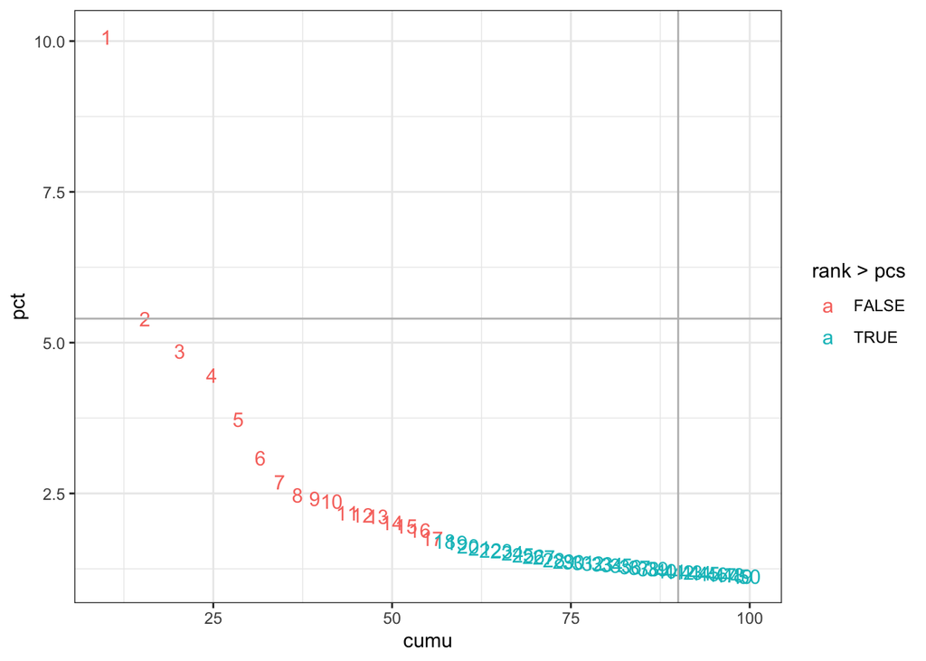

```r
# Create a dataframe with values
plot_df <- data.frame(pct = pct,
           cumu = cumu,
           rank = 1:length(pct))

# Elbow plot to visualize
  ggplot(plot_df, aes(cumu, pct, label = rank, color = rank > pcs)) +
  geom_text() +
  geom_vline(xintercept = 90, color = "grey") +
  geom_hline(yintercept = min(pct[pct > 5]), color = "grey") +
  theme_bw()
```